# Techniki Wizualizacji Danych - PD5

Patryk Wróbel

## Cel zadania

Celem zadania było zbadanie występowania różnego rodzaju problemów związanych z odczytywaniem danych z wykresów.

Wykresy prezentują zmiany w liczbie użytkowników pewnego serwisu VoD na podstawie wyników z 2017 i 2018 roku.

Dane zawarte w materiale zostały wygenerowane na potrzeby badania.

## Wykres 1

Na pierwszym wykresie dane dotyczące poszczególnych lat przedstawione zostały w postaci skumulowanych słupków.

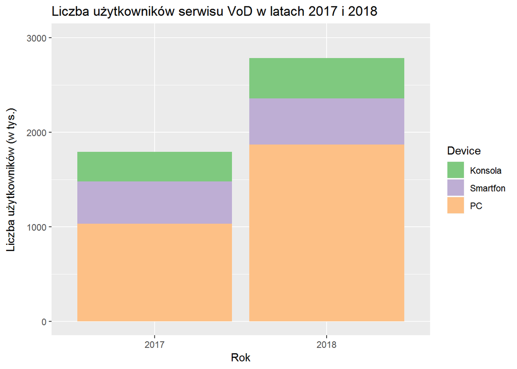

## Wykres 2

Na drugim wykresie dane dotyczące poszczególnych lat przedstawione zostały w postaci osobnych słupków dla poszczególnych typów urządzeń.

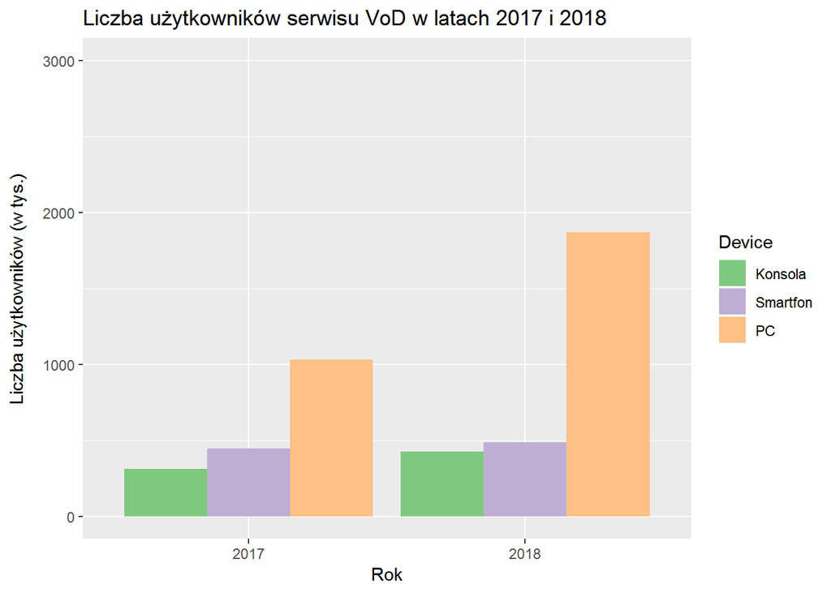

## Wykres 3

Na ostatnim wykresie dane zostały przedstawione w osobnych słupkach, jednak w rozbiciu na typ urządzenia, a nie na rok.

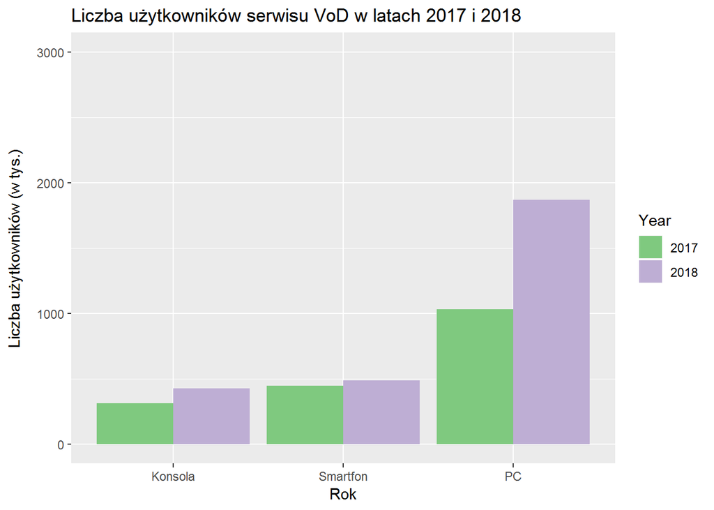

## Ankieta

W ankiecie na podstawie każdego z wyżej zaprezentowanych wykresów należało odpowiedzieć na 2 pytania:

- W którym roku odnotowano większą liczbę użytkowników korzystających ze smartfonów?
- Czy w 2018 roku odnotowano większą liczbę uzytkowników korzystających z konsoli czy ze smartfonów?

Na koniec każdy z ankietowanych poproszony został o wskazanie jego zdaniem najlepszego wykresu do prezentowanych danych.

Link do ankiety: https://docs.google.com/forms/d/e/1FAIpQLSfrIshrbeHaH8zbPOiHpL8P9Gi2z_ilb7-wFLzzQU-S0wpd3A/viewform?vc=0&c=0&w=1

Wyniki przedstawione zostały poniżej:

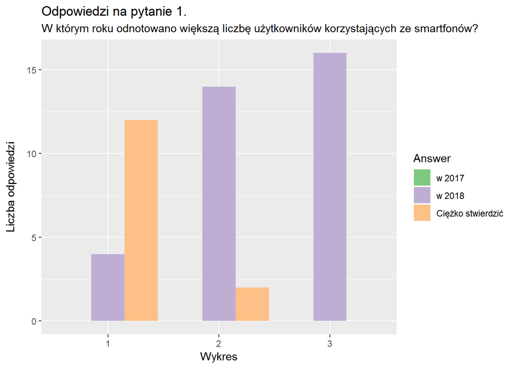

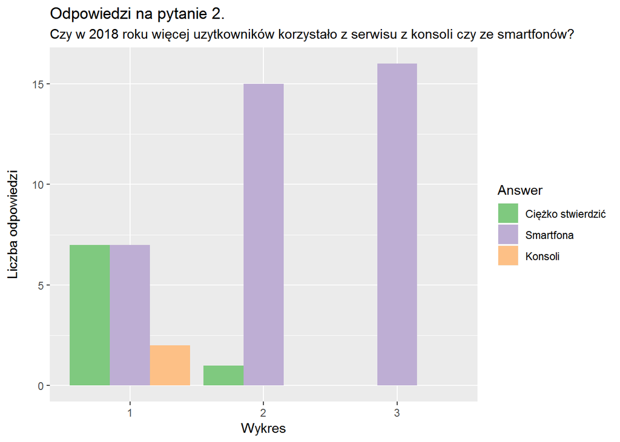

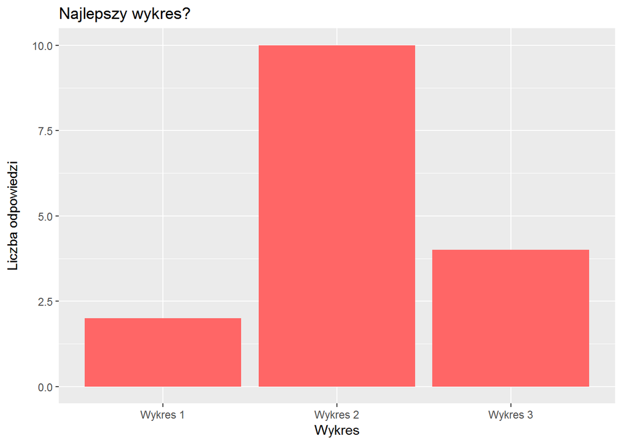

## Podsumowanie

Jak widać wyniki ankiety pokrywają się z przewidywaniami.

Na **wykresie 2.** porównywanie słupków jest o wiele łatwiejsze z uwagi na fakt, że wszystkie zaczynają się na jednej prostej. Wyniki ankiety potwierdzają, że wykres ten jest czytelny i w większym stopniu umożliwia udzielenie poprawnych odpowiedzi na zadane pytania. Dodatkowo wykres ten został **wybrany** przez większość ankietowanych **jako najlepszy**.

Na **wykresie 3.** dane zostały przedstawione w sposób odwrotny do wykresu 2. Słupki zostały tu pogrupowane wg typu urządzenia, a nie roku, którego dotyczą dane. Jako jedyny wykres ten umożliwił **wszystkim ankietowanym** udzielenie **poprawnych odpowiedzi**, mimo że ostatecznie nie został wybrany jako najlepszy wykres.